# tidyexposomics: integrated exposure-omics analysis powered by tidy principles

Jason Laird<sup>1</sup>

1. Department of Environmental Health and Engineering, Johns Hopkins University

March 13, 2025

[figure not shown]

# Introduction

Exposure to environmental factors is a major determinant of health and disease. The exposome is a term that represents the totality of environmental exposures that drive disease and overall health [(Wild et al. 2005)](https://pubmed.ncbi.nlm.nih.gov/16103423/). To tackle the daunting task of characterizing the relationship between a multiplicity of exposures and disease outcomes, epidemiological studies have moved towards exposure wide association studies (ExWAS) where sets of exposures are associated with an outcome [(Chung et al. 2024)](https://academic.oup.com/exposome/article/4/1/osae001/7574628). The advent of high-throughput technologies has enabled profiling of several layers of biological information. These layers too can be integrated to better understand the relationship between exposures and disease outcomes.

The `tidyexposomics` package is designed to facilitate the integration of exposure and omics data to identify exposure-omics associations. We structure our commands to fit into the `tidyverse` framework, where commands are designed to be simplified and intuitive. Here we provide functionality to perform quality control, sample and exposure association analysis, differential abundance analysis, multi-omics integration, and functional enrichment analysis.

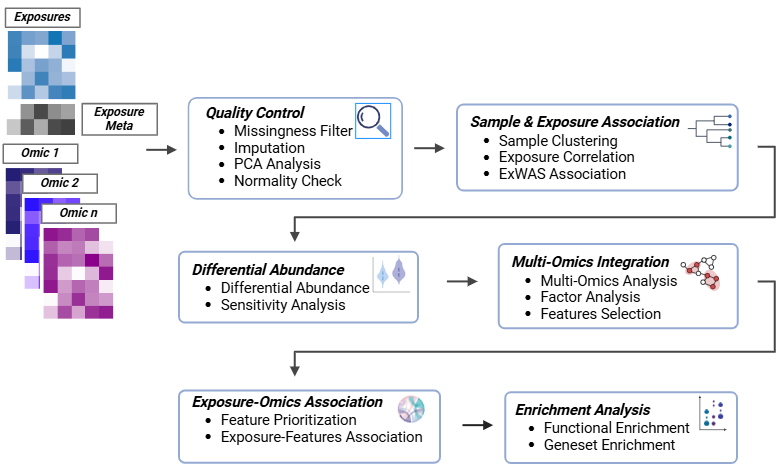

**tidyexposomics pipeline overview.** Exposure and omics data are stored in a MultiAssayExperiment. Data then undergo quality cotnrol, sample and exposure associations, differential abundance analysis, multi-omics integration, and functional enrichment analysis. The pipeline is designed to be flexible and modular, allowing users to customize their analysis.

# Installation

```r
# install the current development version
devtools::install_github("BioNomad/tidyexposomics")
```

# Command Structure

To make the package more user-friendly, we have named our functions to be more intuitive. For example, we use the following naming conventions:

- `associate_*` Associations using models
- `correlate_*` Correlation based approaches
- `run_*` Running more complex pipelines
- `plot_*` Visualizing results
- `filter_*`, `transform_*`, `extract_*`, and `pivot_*` Data pre-processing steps

We provide functionality to either `add` results to the existing object storing the omics/exposure data or to return the direct results using the `get` option. We suggest adding results, as we also include a `run_bibliography` function to generate a bibliography of the workflow. This is useful for keeping track of the pipeline steps.

# Loading Data

To get started we need to load the data. The `expOmicSet` function is used to create a MultiAssayExperiment object that contains the exposure and omics data. As a quick introduction, a MultiAssayExperiment object is a container for storing multiple assays (e.g., omics data) and their associated metadata:

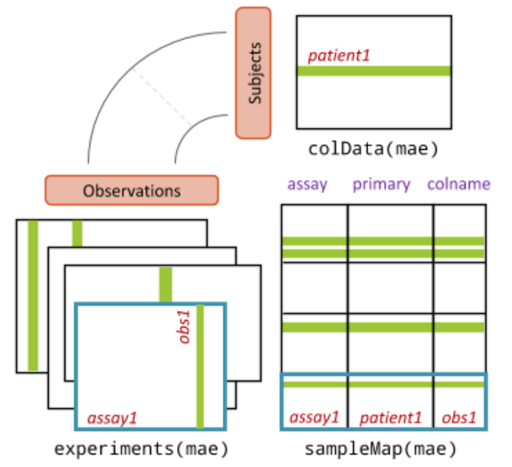

**Overview of the MultiAssayExperiment Object Structure.** Subject level data is captured within the `colData` of the MultiAssayExperiment. Observations are stored within `experiments` slots in the MultiAssayExperiment and `sampleMap` is used to link the data ( [MultiAssay Special Interest Group 2024](https://www.bioconductor.org/packages/release/bioc/vignettes/MultiAssayExperiment/inst/doc/MultiAssayExperiment.html) ).

We use the MultiAssayExperiment object to store the exposure and omics data. The `create_expomicset` function takes several arguments:

- The `var_info` argument is a data frame that contains information about the variables in the exposure meta data.
- The `exposure` argument is a data frame that contains the exposure data,
- The `omics` argument is a list of data frames that contain the omics data.
- The `row_data` argument is a list of data frames that contain information about the rows of each omics data frame.

```r
# Create list of omics data frames
omics_list <- list(
  "CD16+ Monocyte RNA" = cd16_rna,
  "CD4+ T-cell RNA" = cd4_rna,
  "CD4+ T-cell miRNA"= cd4_mirna,
  "CD16+ Monocyte miRNA" = cd16_mirna,
  "Serum Proteomics" = prot_abd_unnorm,
  "Serum Adductomics" = adduct
)

# Create list of omics row data data frames
fdata <- list(
  "CD16+ Monocyte RNA" = cd16_rna_fdata,
  "CD4+ T-cell RNA" = cd4_rna_fdata,
  "CD4+ T-cell miRNA"= cd4_mirna_fdata,
  "CD16+ Monocyte miRNA" = cd16_mirna_fdata,
  "Serum Proteomics" = prot_fdata,
  "Serum Adductomics" = adduct_fdata
)

# Create the expomicset object
expom <- create_expomicset(
  var_info = des,
  exposure = aw_dataset_cv2_filt,
  omics = omics_list,
  row_data = fdata)
```